# (Prosper loan data Exploration Title)

> It is obvious when we plotted the borrower rate against some important categorical variables that borrower rate is different in the following features (isborrowerhomeowner, prosperscore, Term,currently in group) we can say that if you are a house owner you are probably going to have a lower borrowing rate than if you don't owe your house, also for prosperscore low term which means 1 year can be a proof that you will have a lower borrowerrate , also if you look at the currently in group you can see that there is a slight difference that if you aren't in group you will have a lowr borrower rate

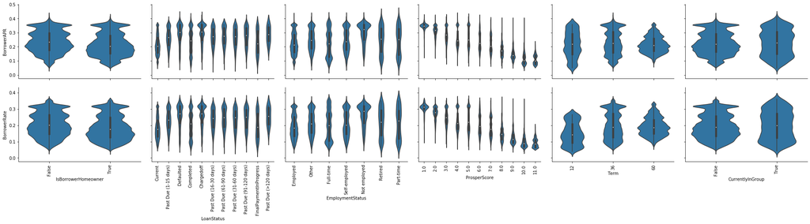

```python
#samples = np.random.choice(df.shape[0], 5000, replace = False)
#df_samp2 = df.loc[samples,:]

def violin(x, y, **kwargs):
    """ Quick hack for creating box plots with seaborn's PairGrid. """
    default_color = sb.color_palette()[0]
    sb.violinplot(x, y, color = default_color)
    plt.xticks(rotation = 90)


plt.figure(figsize = [15, 15])
g = sb.PairGrid(data = df, y_vars = ['BorrowerAPR', 'BorrowerRate'], x_vars = ['IsBorrowerHomeowner', 'LoanStatus','EmploymentStatus','ProsperScore','Term','CurrentlyInGroup'],
                height = 3, aspect = 1.5)
g.map(violin)
plt.show();
```

> violin plot asserted on what we say in the box plot specially concerning the concept of homeowner or not, from the box plot you can say that currently in group or not won't differ in the borrowerrate as their median or average is nearly equal but look at the box plot of currently in group versus borrower rate a large segment of people ( the part below median) has same borrower rate as (small segment of people in the same area below average) that can be a proof that not being in a group has a good chance of having a lower borrower rate

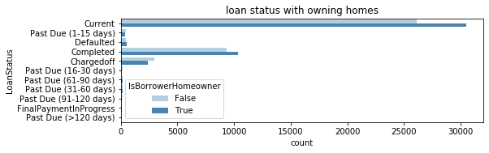

```python
plt.figure(figsize = [8, 8])

# subplot 1: borrower_homeowner vs loanstatus
plt.subplot(3, 1, 1)
sb.countplot(data = df, y = 'LoanStatus', hue = 'IsBorrowerHomeowner', palette = 'Blues')
plt.title('loan status with owning homes')

# subplot 2: employment_status vs. loanstatus
#ax = plt.subplot(3, 1, 2)
#sb.countplot(data = df, y = 'LoanStatus', hue = 'EmploymentStatus', palette = 'Greens')
#ax.legend(ncol = 2) # re-arrange legend to reduce overlapping



plt.show()
```

> you can see from the loan status we have our data that always owning your home as borrower make your loan being current or completed compared to not owning your home , the only case not owning home was higher was in the case when the loan was charged off

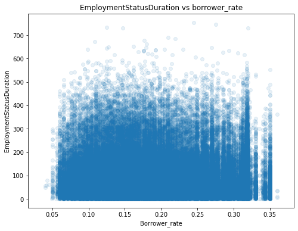

```python
plt.figure(figsize = [8, 6])
plt.scatter(data = df, y = 'EmploymentStatusDuration', x = 'BorrowerRate', alpha = 1/10)
#plt.xlim([0, 3.5])
plt.ylabel('EmploymentStatusDuration')
#plt.yscale('log')
#plt.yticks([500, 1e3, 2e3, 5e3, 1e4, 2e4], [500, '1k', '2k', '5k', '10k', '20k'])
plt.xlabel('Borrower_rate')
plt.title('EmploymentStatusDuration vs borrower_rate')

plt.show()
```

> it seems that the employment status duration doesn't affect the borrower rate as many values on the x axis(means having same borrower rate) has a increasing value in the y value (y_axis) (emolymentStatusDuration), so no clear evidence or correlation that being more duration as employed will help you to get less borrowing rate

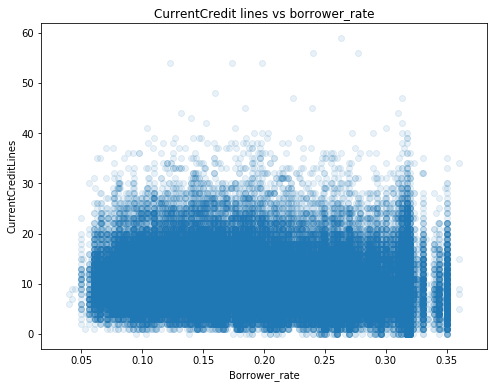

```python
plt.figure(figsize = [8, 6])
plt.scatter(data = df, y = 'CurrentCreditLines', x = 'BorrowerRate', alpha = 1/10)
#plt.xlim([0, 3.5])
plt.ylabel('CurrentCreditLines')
#plt.yscale('log')
#plt.yticks([500, 1e3, 2e3, 5e3, 1e4, 2e4], [500, '1k', '2k', '5k', '10k', '20k'])
plt.xlabel('Borrower_rate')
plt.title('CurrentCredit lines vs borrower_rate')
plt.show()
```

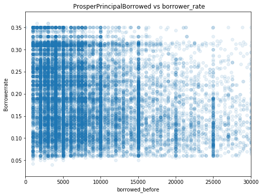

```python
plt.figure(figsize = [8, 6])
plt.scatter(data = df, x = 'ProsperPrincipalBorrowed', y= 'BorrowerRate', alpha = 1/10)
#plt.xlim([0, 3.5])
plt.ylabel('Borrowerrate')
#plt.yscale('log')
#plt.yticks([500, 1e3, 2e3, 5e3, 1e4, 2e4], [500, '1k', '2k', '5k', '10k', '20k'])
plt.xlabel('borrowed_before')
plt.title(' ProsperPrincipalBorrowed vs borrower_rate')
plt.xlim([0,30000])
plt.show()
```

> checking if the prosper principal borrowed can affect the borrower rate , the answer is clearly showing that this isn't true by anyway of ways, the scatter is showing clearly that there isn't a relation and that asserts on the number we got from the correlation map

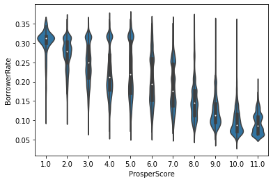

```python
sb.violinplot(data = df , x = 'ProsperScore', y ='BorrowerRate',color=sb.color_palette()[0])
```

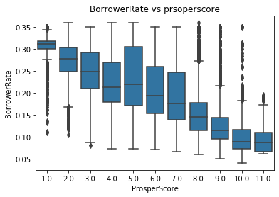

```python
sb.boxplot(data = df , x = 'ProsperScore' , y ='BorrowerRate',color=sb.color_palette()[0])
plt.title('BorrowerRate vs prsoperscore')
```

> It is obvious that when the posperscore increasing ( saying that the risk is low) the borrower rate is decreasing drastically so we can say that when the risk is high the rate of borrower will be too much increased

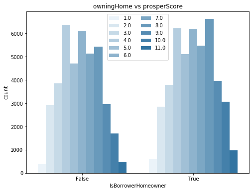

```python
plt.figure(figsize = [8, 6])

sb.countplot(data = df , x='IsBorrowerHomeowner' , hue='ProsperScore',color=sb.color_palette()[0])
plt.legend(loc=0,ncol=2) #bbox_to_anchor=(1, 0.5, 0.25, 0.25)))
plt.title('owningHome vs prosperScore')
```

> Is prsoper score affected by if the borrower owning a home ? yes, it is clearly that prosper score taking scores 5 to 11 is high a lot on the right side of the plot compared to not having the home on the left side of the plot the right part of the plot saying that borrowing home is True proves that clearly

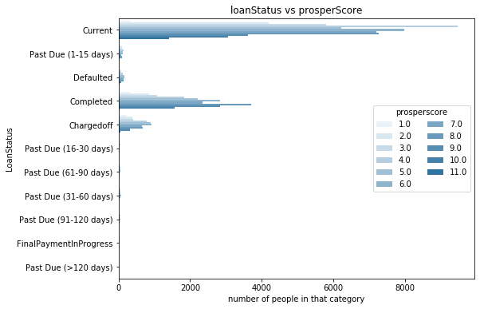

```python
plt.figure(figsize = [8, 6])

sb.countplot(data = df , y='LoanStatus' , hue='ProsperScore',color=sb.color_palette()[0])
plt.legend(loc=0,ncol=2,title="prosperscore") #bbox_to_anchor=(1, 0.5, 0.25, 0.25)))
plt.title('loanStatus vs prosperScore')
plt.xlabel('number of people in that category')
```

> Although this plot doesn't give too much information to say,but we can get that in the case of charged off and current loan status the ratio of the prosperscores takes 7 and above was low compared to the prospoerscores taking lower than 6

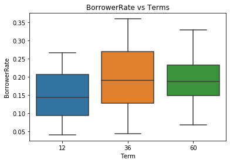

```python
sb.boxplot(data = df , x = 'Term' , y ='BorrowerRate')
plt.title('BorrowerRate vs Terms')
```

> we can see from the box plot that the IQR range of the 36 term is much broader than the 60 and the 12 terms and we even notice something more interesting seeing the 60 terms box plot , the second quartile is even higher than the average of the 12 terms, so in conlusion on average a lon of 60 or 36 terms will take a higher borrower rate compared to 12 terms loan

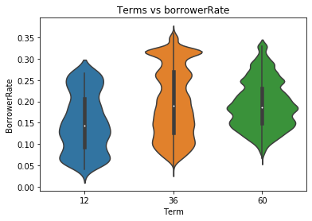

```python
sb.violinplot(data = df , x = 'Term' , y ='BorrowerRate')
plt.title('Terms vs borrowerRate')
```

> It is clear that people applying for loans with 36 and 60 terms are much more higher than people applying for 12 term loan and that the most loans prosper provides is 36 terms, that is the most category people asks for their terms of loan but for me no clear evidence that the terms of loan affect the borrower rate on a clear impact but we must check this variable (term of loan) i na further exploration to have faith whether it affects or not

```python
df['ProsperPrincipalBorrowed'].value_counts()
```

```
4000.00     1775
5000.00     1285
2000.00     1071
3000.00     1038
15000.00     926
            ...
6361.35        1
8364.21        1
3365.00        1
6180.00        1
2560.00        1
Name: ProsperPrincipalBorrowed, Length: 1368, dtype: int64
```

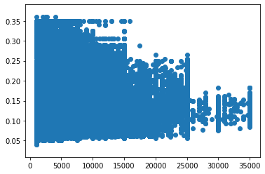

```python
plt.scatter(data = df , x='LoanOriginalAmount',y='BorrowerRate')
```

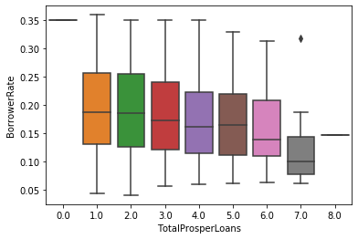

```python
sb.boxplot(data = df , x='TotalProsperLoans',y='BorrowerRate')
```

> checking the total prosper loans against the borrower rate is based on the question deos taking more than one loan will affect my borrower rate ? , looking on the curve we see that the range of people taking the first loan is more near not the same though as people taking their second or third or fourth loan

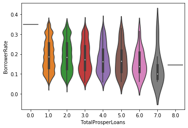

```python
sb.violinplot(data = df , x='TotalProsperLoans',y='BorrowerRate')
```

> you can see from the violin plot if comparing the 1,2,3 that higher portions taking their second and third loan with same borrowing rate as the portion taking their first loan so that means that a customer can have their second loan and have the samr borrowing rate as another customer having his first loan , that is interesting

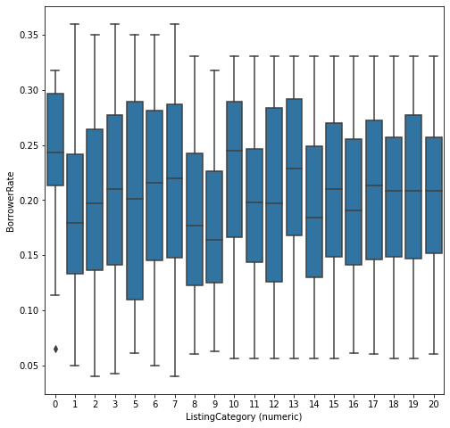

```python
plt.figure(figsize=[8,8])

sb.boxplot(data = df , x ='ListingCategory (numeric)' , y='BorrowerRate',color=sb.color_palette()[0])
```

> the interesting part here that this visulaization can tell us a lot about if the listing category which here means the reason that customer giving for taking this loan can affect the borrowing rate , we can see clearly that some categories is the same spread as others but it takes a less borrowing rate averge compared to them

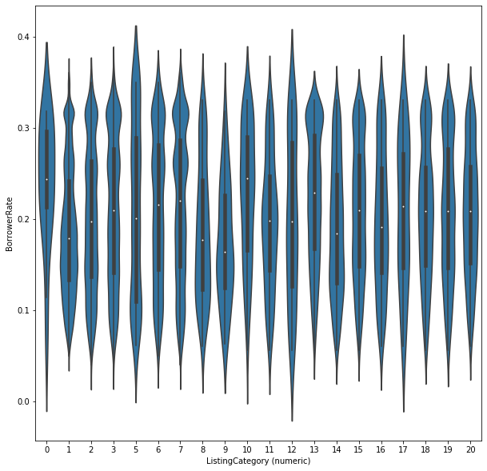

```python
plt.figure(figsize=[10,10])
sb.violinplot(data = df , x ='ListingCategory (numeric)' , y='BorrowerRate',color=sb.color_palette()[0],)
```

> the violin plot maked it clearly that the difference between the averages of the categoris isn't due to like an example a higher portion of people is in the top of the plot, no that isn't the case. we can see that plot 2 and plot 3 are nearly identical in the violin plot but we can see that category 2 takes a lower borrower rate on average than category 3 , aslo that is the case in categories 14,15,16 we see category 15 takes a higher borrower rate on average also we can see dclearly that the listing category play a role in the borrower rate percentage

### Talk about some of the relationships you observed in this part of the investigation. How did the feature(s) of interest vary with other features in the dataset?

> the feature of interest is the borrower rate, we can see that borrower rate is affected by the listing cateogry also it is affected by if the borrower rate is a home owner or not , the third feature that affect our main feature is the prosperscore

### Did you observe any interesting relationships between the other features (not the main feature(s) of interest)?

> loan status has a relation with the prosperscore as the the prosperscore give to the customer really indicates to predict if the customer loan status will be charged off or completed aslo we can say that there is a strong relation between prosperscore and is borrower home owner or not ,owning home helps you get a high prosperscores

## Multivariate Exploration

> Create plots of three or more variables to investigate your data even further. Make sure that your investigations are justified, and follow from your work in the previous sections.

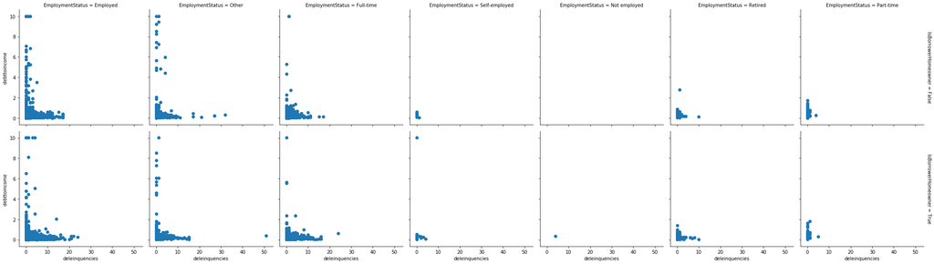

```python
# create faceted heat maps on levels of cut and clarity
g = sb.FacetGrid(data = df, col = 'EmploymentStatus', row = 'IsBorrowerHomeowner', size = 4,
                 margin_titles = True)
g.map(plt.scatter, 'CurrentDelinquencies', 'DebtToIncomeRatio')
g.set_xlabels('deleinquencies')
g.set_ylabels('debttoincome ')

plt.show()
```

> Trying to plot the relation between the current delequnices and debt to income ratio based on emplyment status and if the borrower is a home owner or not, we didn't find an interesting relation or a piece of information to have

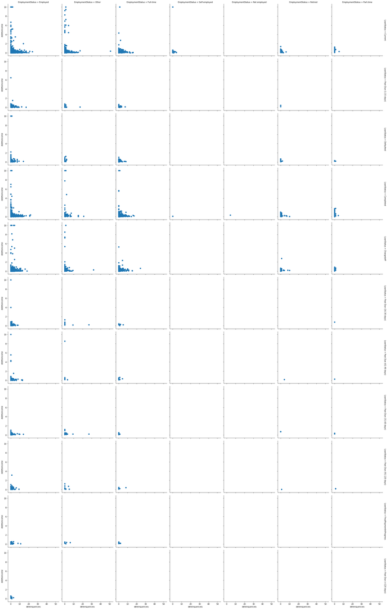

```python
# create faceted heat maps on levels of cut and clarity
g = sb.FacetGrid(data = df, col = 'EmploymentStatus', row = 'LoanStatus', size = 4,
                 margin_titles = True)
g.map(plt.scatter, 'CurrentDelinquencies', 'DebtToIncomeRatio')
g.set_xlabels('deleinquencies')
g.set_ylabels('debttoincome ')

plt.show()
```

> trying to make the same plot of current delequinices with the debt to income ratio but with the respect to the loan status and employment status, also we didn't find anything useful considering a relation or a correlation to get

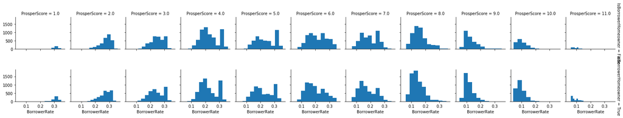

```python
# create faceted heat maps on levels of cut and clarity
plt.figure(figsize=[10,10])
g = sb.FacetGrid(data = df, col = 'ProsperScore', row = 'IsBorrowerHomeowner', size = 2,
                 margin_titles = True)
g.map(plt.hist, 'BorrowerRate')
#g.set_xlabels('Borrower Home owner or not')
#g.set_ylabels('debttoincome ')

plt.show()
```

> we can find from the plot of multivariate plot that indexed by the isthe borrower home owner or not and we indexed the columns by a prosperscore it is clearly with no doubt that when you owns your own home and has a higher prosperscore your borrowing rate will be less compared to if having a lower prosperscore and doesn't have home

> the plot tells us something more important that we can compare the borrower rate with the if the borrower a home owner or not see if the prosperscore is 5 or 6 and even higher you can see that the histogram saying the answer clearly that higher portions are in the case of lower borrower rate, more scientfically and ordered to say the case of homeborrower is true the histograms are really right skewed saying that the distribution at higher borrower rates is less or smaller

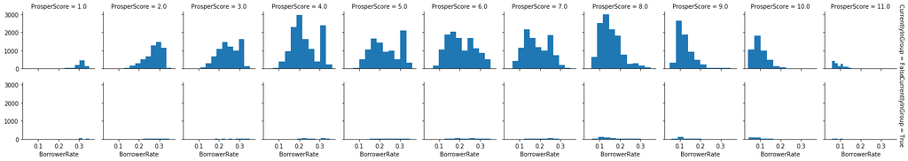

```python
# create faceted heat maps on levels of cut and clarity
plt.figure(figsize=[10,10])
g = sb.FacetGrid(data = df, col = 'ProsperScore', row = 'CurrentlyInGroup', size = 2,
                 margin_titles = True)
g.map(plt.hist, 'BorrowerRate')
#g.set_xlabels('Borrower Home owner or not')
#g.set_ylabels('debttoincome ')

plt.show()
```

> this plot is useful because it tells us clearly that we can't take whether you are a currently in a group or not by a consideration as our data is mostly contains people that aren't in a group

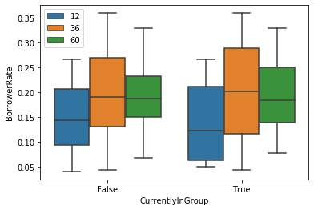

```python
sb.boxplot(data = df , y = 'BorrowerRate' , x='CurrentlyInGroup',hue = 'Term')
plt.legend(loc=0)
```

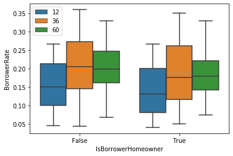

```python
sb.boxplot(data = df , y = 'BorrowerRate' , x='IsBorrowerHomeowner',hue = 'Term')
plt.legend(loc=0,title="Terms of loan")
```

> the plot here is comparing if the borrower is a home owner or not versus the term of the loan and seeing the plot distribution of the borrower rate, it is clearly with no doubt that having your home makes your borrower rate much lower than not having the house and also that the short term loans has a lower borrower rate

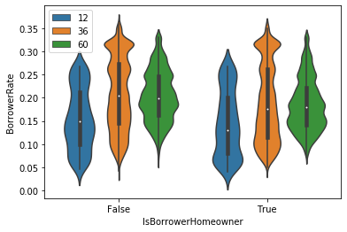

```python
sb.violinplot(data = df , y = 'BorrowerRate' , x='IsBorrowerHomeowner',hue = 'Term')
plt.legend(loc=0,title="Terms of loan")
```

> the violin plot here is comparing the portions of people taking a range of borrower rates versus the terms of the loan and whether you are a home owner or not, you can see clearly the right side of plot stating that borrower owns its home , the range saying the *portions* or *the width of the plot* taking a lower borrower rate is bigger or wider than the other category of not having their house

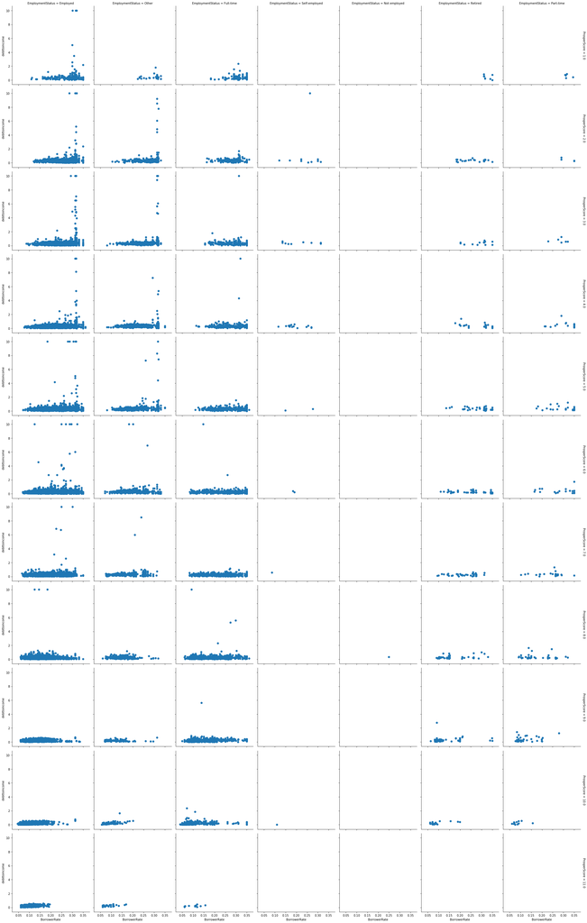

```python
# create faceted heat maps on levels of cut and clarity
g = sb.FacetGrid(data = df, col = 'EmploymentStatus', row = 'ProsperScore', size = 4,
                 margin_titles = True)
g.map(plt.scatter, 'BorrowerRate', 'DebtToIncomeRatio')
g.set_xlabels('BorrowerRate')
g.set_ylabels('debttoincome ')

plt.show()
```

> this plot isn't much useful as there is no clear evidence on correlation It is clear that when the ProsperScore increase the borrower rate become smaller at the beginning of the x axis and also you can see that their ratio concerning debt to income, is lower and no points in the higher comparing to y axis

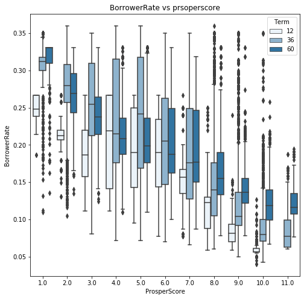

```python
plt.figure(figsize=[8,8])
sb.boxplot(data = df , x = 'ProsperScore' , y ='BorrowerRate',hue='Term',color=sb.color_palette()[0])
plt.title('BorrowerRate vs prsoperscore')
```

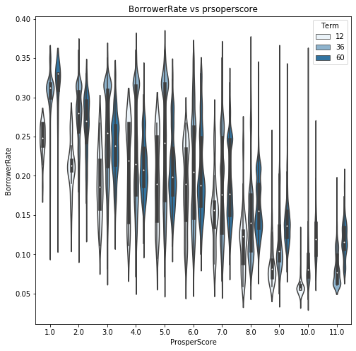

```python
plt.figure(figsize=[8,8])
sb.violinplot(data = df , x = 'ProsperScore' , y ='BorrowerRate',hue='Term',color=sb.color_palette()[0])
plt.title('BorrowerRate vs prsoperscore')
```

> the violin plot here indicating the prosper score distribution on x axis versus the borrower rate on the y axis and the plots also further divided or indexed by the term of the loan, from the violin plot especially high prosperscores we can see clearly that people that has a high borrowerrate is considered an outliers compared to the lower prosper scores on the left side of the plot

### Talk about some of the relationships you observed in this part of the investigation. Were there features that strengthened each other in terms of looking at your feature(s) of interest?

> from the Multivariate plot,bivariate plot we can clearly say that thee are some factors that help us to now what affects the borrower rate, these are (isborrowerhomeowner, prosperscore , the listing cateogory

### Were there any interesting or surprising interactions between features?

> The currently in group variable in the first seems to have a clear impact on the borrower rate but when you further investigate and used the facetgrid and saw the scatter plot you really discover that you can't tell whether currently in group has effect or not as the number of data or loans available in the currently in group especially if the answer yes isn't comparable to the data available in the category of currently in group if the answer is no

> At the end of your report, make sure that you export the notebook as an html file from the `File > Download as... > HTML` menu. Make sure you keep track of where the exported file goes, so you can put it in the same folder as this notebook for project submission. Also, make sure you remove all of the quote-formatted guide notes like this one before you finish your report!